# My Class Notes: Theories and Building your text

# 1 Today’s Tasks:

- Which grand theory speaks to you most?
- How about a mid-level or specific theory?
- What kinds of theoretical frameworks have you come across in your studies so far?
- Which research questions (RQs) can be answered using these theories?

# 2 Building the outline:

This example, based on my research, demonstrates how you can begin structuring the skeleton of your text and organising your ideas for your own projects. It is a good exercise that will help you develop your research proposal.

Try it yourself, and don’t get stuck on selecting the perfect theory—research is an evolving process, and you can refine your approach as you progress.

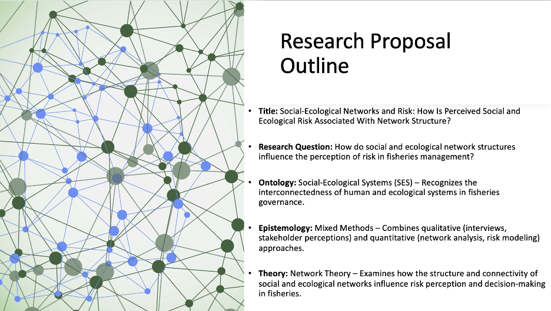

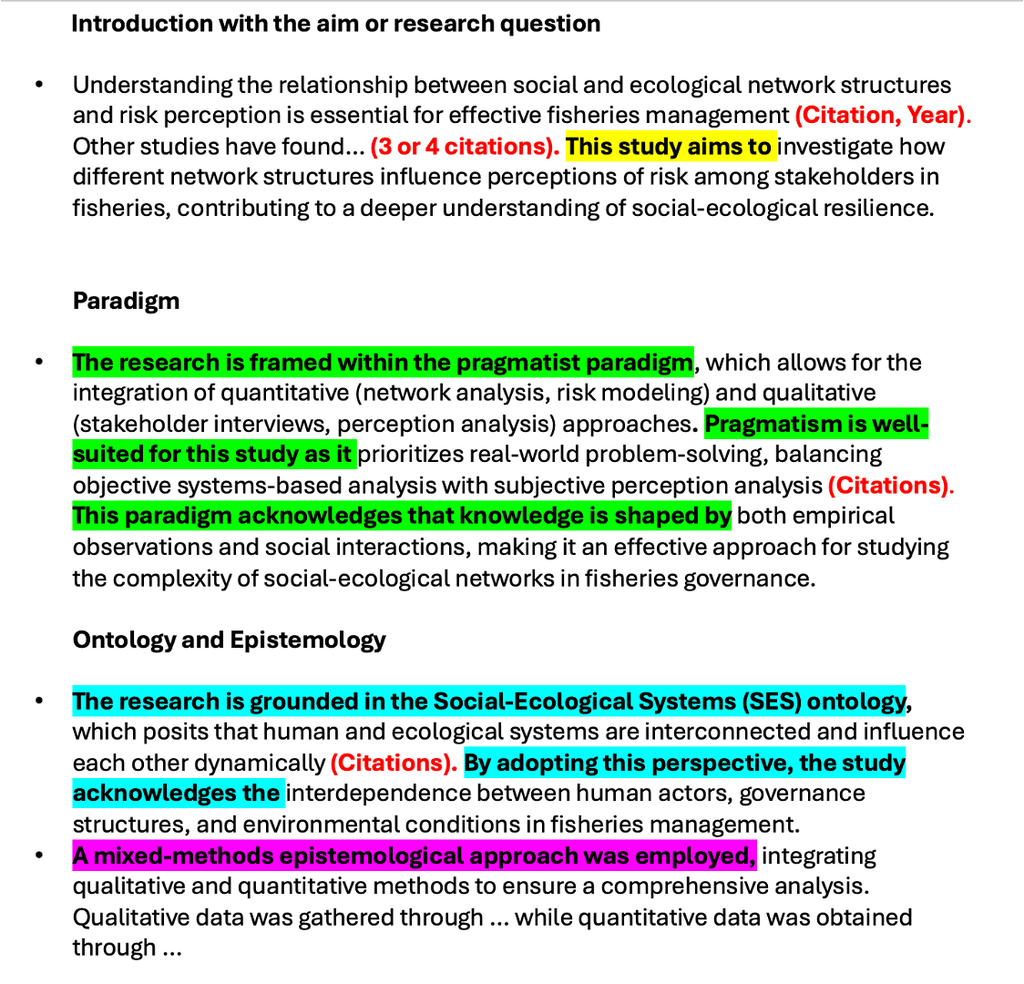

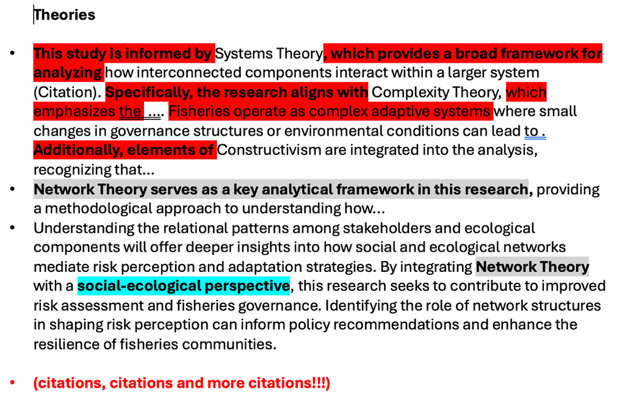

# 3 For those without a topic

This is a list of topics that you could choose to do research on. Maybe it helps?

## 3.1 Politics

1️⃣ Political Institutions & Governance: Studies the structure, function, and effectiveness of governments, electoral systems, and political accountability mechanisms.

2️⃣ Democracy & Authoritarianism: Examines democratic development, challenges to democracy, the rise of authoritarianism, and hybrid political systems.

3️⃣ International Relations & Global Politics: Focuses on diplomacy, global governance, international organisations, foreign policy, and power dynamics among states.

4️⃣ Political Ideologies & Movements: Explores the evolution and impact of political ideologies (e.g., liberalism, socialism, conservatism) and social movements (e.g., feminism, nationalism).

5️⃣ Public Policy & Administration: Analyses how policies are formulated, implemented, and evaluated in areas such as health, education, welfare, and environmental governance.

6️⃣ Conflict, Security & Peace Studies: Investigates causes of war, peace-building efforts, security threats (terrorism, cyberwarfare), and the role of military interventions.

7️⃣ Comparative Politics: Compares political systems, institutions, and governance models across different countries to identify patterns and differences.

8️⃣ Political Economy: Studies the relationship between politics and economics, including global trade, economic inequality, and the role of the state in markets.

9️⃣ Human Rights & Political Justice: Examines the protection of human rights, international law, transitional justice, and responses to political oppression.

🔟 Environmental Politics & Climate Policy: Analyses the role of governments and international institutions in addressing climate change, sustainability, and environmental justice.

## 3.2 IR

1️⃣ Theories of International Relations: Examines foundational and evolving theories such as Realism, Liberalism, Constructivism, and Critical Theories to understand state behavior and global interactions.

2️⃣ Global Governance & International Organisations: Investigates the role and effectiveness of international institutions (e.g., UN, NATO, WTO) and regional organizations (e.g., EU, ASEAN, AU) in maintaining global order.

3️⃣ Foreign Policy & Diplomacy: Analises how states formulate and implement foreign policies, engage in diplomacy, and respond to global challenges through strategic decision-making.

4️⃣ Security & Conflict Studies: Explores issues of war, peace, military strategies, cyber warfare, counterterrorism, and the role of nuclear deterrence in international security.

5️⃣ International Political Economy (IPE): Studies the intersection of politics and economics, including trade policies, global financial institutions, economic development, and the impact of globalization.

6️⃣ Human Rights & International Law: Examines how international legal frameworks protect human rights, address war crimes, and regulate state and non-state actors in global governance.

7️⃣ Environmental Politics & Climate Diplomacy: Investigates international efforts to combat climate change, the role of global agreements (e.g., Paris Agreement), and environmental security issues.

8️⃣ Geopolitics & Strategic Studies: Focuses on power struggles between global and regional powers, shifting alliances, and the impact of geography on international conflicts and cooperation.

9️⃣ Technology & International Relations: Analszes how emerging technologies (AI, cyber warfare, surveillance) influence diplomacy, security, and international competition.

🔟 Migration & Refugee Politics: Studies the political and humanitarian challenges of forced displacement, asylum policies, and international cooperation in managing migration crises.